```python
from IPython.display import HTML
HTML('''<script>
code_show=true;
function code_toggle() {
 if (code_show){
 $('div.input').hide();
 } else {
 $('div.input').show();
 }
 code_show = !code_show
}
$( document ).ready(code_toggle);
</script>
<form action="javascript:code_toggle()"><input type="submit" value="Click here to toggle on/off the raw code."></form>''')
```

# ㅁOne Point Tutorial II - `Pandas`

빅데이터 분석 초급과정 with 관악구, KMR

2023 1st | All rights reserved by Wooseok Song

# 1. Pandas를 사용하는 이유

NumPy 튜토리얼에서 언급했듯, 파이썬은 원래 데이터 분석에 특화된 언어가 아니다.  
Pandas는 NumPy와 함께 파이썬의 대표적인 데이터 사이언스 라이브러리로 NumPy가 기본적인 다차원 벡터화 연산을 도와준다고 하면, Pandas는 Numpy를 기반으로 하여 데이터 프레임의 활용이나 피벗테이블 생성 등이 가능하며, 데이터의 입/출력 등 여러 응용 기능을 제공한다.  
또한, Pandas는 리스트, 튜플 및 딕셔너리 등의 Python 기본 자료구조 외에 Series와 DataFrame이라는 고유 자료 구조를 활용한다.

R에서는 유사한 기능을 사용하기 위하여 일반적으로 아래와 같은 패키지/라이브러리를 이용한다.

> - data.frame/data.table (데이터를 담는 자료 구조)
> - tidyr (wraggling; messy한 데이터셋을 tidy한 데이터셋으로 만들기)
> - dplyr (handling; 여러 인사이트를 반영하여 변수를 추가/수정/삭제 하고 요약하기)

Pandas에서도 데이터 시각화가 가능하나, R의 ggplot2와 비교하기엔 지나치게 간소한 기능만 지원한다.

### !Pandas는

1. 모든 계산은 numpy 기반으로 수행
2. 행은 index, 열은 변수명으로 접근할 수 있게 하여 실수를 줄이고 가독성을 제고
3. 데이터분석에 특화된 전용 함수들을 제공
4. 자동 혹은 사용자 지정에 따라 축을 설정하고 데이터를 정렬/연산
5. 시계열 및 비시계열을 모두 처리 가능
6. 누락 데이터 처리 용이
7. RDBMS에서 수행하는 데이터 처리 기능 지원

*이후 강의 흐름

1. pd.Series에 대한 소개 및 생성/활용
2. pd.DataFrame에 대한 소개 및 생성/활용
3. Series와 DF객체를 가지고 자주 만나게 될 기본 task들
   > 1. Reindex
   > 2. Dropping 관측치 or 변수
   > 3. 함수 적용
   > 4. 연산
   > 5. 정렬
   > 6. Summary statistics
   > 7. filter/fill NA

포인트는,

1. Pandas의 매서드들을 적용하게 될 핵심 개체인 pd.Series와 pd.DataFrame에 대해 이해하고
2. 이를 활용하여 기본 task들을 무엇을, 어떻게 수행하게 되는지 이해하고 응용

결과적으로 **R에서는 base 자료구조이고 함수인 것들이 Python에서는 존재하지 않음에서 오는 비대칭을 해소**하기 위함

# 2. pd.Series에 대한 소개 및 생성/활용

## 2.1 pd.Series란?

one dimensional data를 담는 객체(사실은 클래스)로서, 리스트의 성격과 딕셔너리의 성격이 섞여있다.  
차원은 한 개이나, 실제 형태는 m x 2 이다.

## 2.2 pd.Series 객체의 주요 attribute

`pd.Series.shape`

> 객체의 shape은 m행 2열이다.

`Series.values`

> 객체의 데이터 부분에서 **내용물**이라고 생각하면 된다. 이 속성에는 np.array가 들어가게 된다.

`Series.index`

> 이 객체의 데이터 부분에서 **껍데기**라고 생각하면 된다. 이 속성에는 pd.Index라는 객체가 들어간다.

> > 참고 : pd.Index말고 응용버전인 MultIndex나 pd.DatetimeIndex도 들어갈 수 있다.  
> > $\qquad$pd.Index는 immutable(변경이 불가능)한데 이것은 안정성 면에서 중요하다.

## 2.3. pd.Series 객체를 생성하는 방법들

다양한 방법으로 생성할 순 있지만 거의 아래의 방식대로 생성한다,

```python
import numpy as np
import pandas as pd
```

```python
a = pd.Series([1, 2, 3, 4], index = ['a', 'b', 'c', 'd'])
a
```

```
a    1
b    2
c    3
d    4
dtype: int64
```

```python
b = pd.Series(np.array([1, 2, 3, 4]), index = ['a', 'b', 'c', 'd'])
```

```python
a == b
```

```
a    True
b    True
c    True
d    True
dtype: bool
```

```python
c = pd.Series([1, 2, 3, 4], ['a', 'b', 'c', 'd'])
```

```python
print(a == b)
print(b == c)
print(c == a)
```

```
a    True
b    True
c    True
d    True
dtype: bool
a    True
b    True
c    True
d    True
dtype: bool
a    True
b    True
c    True
d    True
dtype: bool
```

## 2.4 pd.Series 객체를 indexing&slicing을 통해 접근&변경하는 법

일차원 np.array에 접근하는 방법에서 추가로 문자 index로 접근이 가능하다!

이 부분 뿐만 아니라 전체적으로 np.array의 기능 확장 버전이라고 생각하는 게 전반적으로 이해하는 데 도움이 된다.

```python
a['a']
```

```
1
```

```python
a[:]
```

```
a    1
b    2
c    3
d    4
dtype: int64
```

```python
a[::2]
```

```
a    1
c    3
dtype: int64
```

```python
a['a'] = 2
```

```python
a
```

```
a    2
b    2
c    3
d    4
dtype: int64
```

```python
condition = a > 2
```

```python
a[condition]
```

```
c    3
d    4
dtype: int64
```

```python
a[a > 2]
```

```
c    3
d    4
dtype: int64
```

### boolean indexing for Series

```python
a[a > 2] = 10
```

```python
a
```

```
a     2
b     2
c    10
d    10
dtype: int64
```

## 2.5 operation for pd.Series 객체

np.array와 거의 똑같은 pd.Series 객체의 연산을 지원한다.

```python
sr1 = pd.Series(np.arange(1,13, dtype = np.int))
sr1
```

```
0      1
1      2
2      3
3      4
4      5
5      6
6      7
7      8
8      9
9     10
10    11
11    12
dtype: int32
```

```python
sr1.sum()
```

```
78
```

```python
sr1.mean()
```

```
6.5
```

```python
sr1.std() # numpy와 달리 n-1로 나눠준다.
```

```
3.605551275463989
```

```python
sr1.max()
```

```
12
```

## 2.6 operation for 2개의 pd.Series 객체

np.array와 정말 똑같은 pd.Series 객체들간의 연산을 지원한다.

```python
sr1 = pd.Series([1, 2, 3, 4], index = ['a', 'b', 'c', 'd'])
sr2 = pd.Series([5, 6, 7, 8], index = ['a', 'b', 'c', 'd'])
```

```python
sr1
```

```
a    1
b    2
c    3
d    4
dtype: int64
```

```python
sr2
```

```
a    5
b    6
c    7
d    8
dtype: int64
```

```python
sr1 + sr2
```

```
a     6
b     8
c    10
d    12
dtype: int64
```

```python
sr1 - sr2
```

```
a   -4
b   -4
c   -4
d   -4
dtype: int64
```

```python
sr1 / sr2
```

```
a    0.200000
b    0.333333
c    0.428571
d    0.500000
dtype: float64
```

```python
sr1 * sr2
```

```
a     5
b    12
c    21
d    32
dtype: int64
```

```python
sr1.dot(sr2)
```

```
70
```

```python
pd.concat((sr1, sr2), 0)
```

```
a    1
b    2
c    3
d    4
a    5
b    6
c    7
d    8
dtype: int64
```

```python
pd.concat((sr1, sr2), 1)
```

|  | 0 | 1 |
| --- | --- | --- |
| a | 1 | 5 |
| b | 2 | 6 |
| c | 3 | 7 |
| d | 4 | 8 |

```python
type(pd.concat((sr1, sr2), 1))
```

```
pandas.core.frame.DataFrame
```

#### 다른 점은 **shape이 다른** 객체들간의 연산도 지원한다는 것이다.

```python
sr1 = pd.Series([1, 2, 3, 4], index = ['a', 'b', 'c', 'd'])
sr2 = pd.Series([5, 6, 7, 8, 9], index = ['a', 'b', 'c', 'd', 'e'])
```

```python
sr1
```

```
a    1
b    2
c    3
d    4
dtype: int64
```

```python
sr2
```

```
a    5
b    6
c    7
d    8
e    9
dtype: int64
```

```python
sr1 + sr2
```

```
a     6.0
b     8.0
c    10.0
d    12.0
e     NaN
dtype: float64
```

**다양한 것이 가능하다. 연산은 기본적으로 인덱스 기준.**

```python
sr11 = pd.Series([1, 2, 3, 4], index = ['a', 'b', 'c', 'd'])
sr12 = pd.Series([5, 6, 7, 8], index = ['d', 'c', 'b', 'a'])
sr13 = pd.Series([5, 6, 7, 8, 9], index = ['e', 'd', 'c', 'b', 'a'])
```

```python
sr11
```

```
a    1
b    2
c    3
d    4
dtype: int64
```

```python
sr12
```

```
d    5
c    6
b    7
a    8
dtype: int64
```

```python
sr11 + sr12
```

```
a    9
b    9
c    9
d    9
dtype: int64
```

```python
sr11 + sr13
```

```
a    10.0
b    10.0
c    10.0
d    10.0
e     NaN
dtype: float64
```

## 2.7 pd.Series with NaN values

```python
sr3 = sr1 + sr2
```

```python
sr3
```

```
a     6.0
b     8.0
c    10.0
d    12.0
e     NaN
dtype: float64
```

```python
pd.isnull(sr3)
```

```
a    False
b    False
c    False
d    False
e     True
dtype: bool
```

```python
pd.notnull(sr3)
```

```
a     True
b     True
c     True
d     True
e    False
dtype: bool
```

```python
sr3[pd.notnull(sr3)] # 결측값 제외
```

```
a     6.0
b     8.0
c    10.0
d    12.0
dtype: float64
```

## 2.8 pd.Series.index.name

생각보다 자주 쓴다.

```python
sr3
```

```
a     6.0
b     8.0
c    10.0
d    12.0
e     NaN
dtype: float64
```

```python
sr3.index
```

```
Index(['a', 'b', 'c', 'd', 'e'], dtype='object')
```

```python
sr3.index.name = 'index_name'
```

```python
sr3 # 더 예쁘다.
```

```
index_name
a     6.0
b     8.0
c    10.0
d    12.0
e     NaN
dtype: float64
```

# 3. pd.DataFrame에 대한 짧은 소개와 생성하는 방법

## 3.1 pd.DataFrame이란?

two dimensional data를 담는 객체이다.

## 3.2 pd.DataFrame 객체의 주요 attribute

`DataFrame.shape`

> 객체의 shape은 m행, n열이다.

`DataFrame.values`

> 객체의 데이터 **내용물**이라고 생각하면 된다. 이 속성에는 2차원 np.array가 들어가게 된다.

`DataFrame.index`

> 객체 데이터의 **행별 이름**이라고 생각하면 된다. 이 속성에는 pd.Index라는 객체가 들어간다.

> > 참고 : pd.Index는 immutable(변경이 불가능)한데 이것은 안정성 면에서 중요하다.

`DataFrame.column`

> 객체 데이터의 **열별 이름, 곧 변수명**이라고 생각하면 된다.

## 3.3. pd.DataFrame 객체를 생성하는 방법들

다양한 방법으로 생성할 순 있지만 거의 아래의 방식대로 생성한다,

### 3.3.1 Dictionary로 생성하는 방법

```python
data = {'score1' : ['91', '94', '97', '100'],
        'score2' : np.arange(100, 90, -3)}
```

```python
data
```

```
{'score1': ['91', '94', '97', '100'], 'score2': array([100,  97,  94,  91])}
```

```python
data_2 = {'score1' : ['91', '94', '97', '100', '49'],
          'score2' : np.arange(1, 6)}
```

```python
data_2
```

```
{'score1': ['91', '94', '97', '100', '49'], 'score2': array([1, 2, 3, 4, 5])}
```

```python
type(data)
```

```
dict
```

```python
df1 = pd.DataFrame(data = data, index = ['a', 'b', 'c', 'd'])
df1
```

|  | score1 | score2 |
| --- | --- | --- |
| a | 91 | 100 |
| b | 94 | 97 |
| c | 97 | 94 |
| d | 100 | 91 |

```python
type(df1)
```

```
pandas.core.frame.DataFrame
```

```python
df11 = pd.DataFrame(data, ['a', 'b', 'c', 'd'])
df11
```

|  | score1 | score2 |
| --- | --- | --- |
| a | 91 | 100 |
| b | 94 | 97 |
| c | 97 | 94 |
| d | 100 | 91 |

```python
df2 = pd.DataFrame(data_2)
```

### 3.3.2 Two dimensional np.array로 생성하는 방법 (list of list도 가능)

```python
data = np.arange(8).reshape(4,2)
```

```python
data
```

```
array([[0, 1],
       [2, 3],
       [4, 5],
       [6, 7]])
```

```python
df1 = pd.DataFrame(data = data, index = ['a', 'b', 'c', 'd'])
df1
```

|  | 0 | 1 |
| --- | --- | --- |
| a | 0 | 1 |
| b | 2 | 3 |
| c | 4 | 5 |
| d | 6 | 7 |

## 3.4 pd.DataFrame 객체를 indexing&slicing을 통해 접근&변경하는 법

`iloc` : **2차원 np.array처럼** ~행 ~열에 접근할 때 사용한다,

`loc` : index명 및 column명을 이용하여 접근할 때 사용한다. 이 때 index는 필수적으로 정의 되어야 한다.

`ix`는 이제 안쓴다,

```python
data = np.array([[1, 2, 3, 4],
                 [5, 6, 7, 8],
                 [9, 10, 11, 12]],dtype = np.int)
data
```

```
array([[ 1,  2,  3,  4],
       [ 5,  6,  7,  8],
       [ 9, 10, 11, 12]])
```

```python
df1 = pd.DataFrame(data, index = ['a', 'b', 'c'],
                   columns = ['score1', 'score2', 'score3', 'score4'])
df1
```

[output not shown]

```python
df1.iloc[1, 2] # 2행 3열에 접근하는 방법1
```

```
100
```

```python
df1.iloc[1][2] # 2행 3열에 접근하는 방법2
```

```
100
```

```python
df1.iloc[:, 2]
```

```
a      3
b    100
c     11
Name: score3, dtype: int32
```

```python
# 이렇게 하면 안돼요.
df1.iloc[:][2]
```

[output not shown]

```python
df1.loc['b', 'score3'] # b행의 score3값(2행 3열)에 접근하는 방법1
```

```
100
```

```python
df1.loc['b']['score3'] # b행의 score3값(2행 3열)에 접근하는 방법2
```

```
100
```

```python
df1.loc['b']
```

```
score1      5
score2      6
score3    100
score4      8
Name: b, dtype: int32
```

```python
# 이렇게 하면 안돼요.
df1.loc['score3']
```

[output not shown]

```python
df1.loc[:, 'score3']
```

```
a      3
b    100
c     11
Name: score3, dtype: int32
```

```python
df1.loc[:]['score3']
```

```
a      3
b    100
c     11
Name: score3, dtype: int32
```

```python
df1.score3
```

```
a      3
b    100
c     11
Name: score3, dtype: int32
```

```python
df1.score3[1] # score3열의 두 번째 행 값에 접근하는 방법
```

```
100
```

```python
# 이렇게 하면 안돼요.
df1.a
```

```
---------------------------------------------------------------------------
AttributeError                            Traceback (most recent call last)
Input In [150], in <cell line: 2>()
      1 # 이렇게 하면 안돼요.
----> 2 df1.a

File ~\anaconda3\lib\site-packages\pandas\core\generic.py:5575, in NDFrame.__getattr__(self, name)
   5568 if (
   5569     name not in self._internal_names_set
   5570     and name not in self._metadata
   5571     and name not in self._accessors
   5572     and self._info_axis._can_hold_identifiers_and_holds_name(name)
   5573 ):
   5574     return self[name]
-> 5575 return object.__getattribute__(self, name)

AttributeError: 'DataFrame' object has no attribute 'a'
```

```python
df1.loc['b']['score3'] = 100 # b행의 score3값(2행 3열)에 접근하여 변경
```

```python
df1
```

|  | score1 | score2 | score3 | score4 |
| --- | --- | --- | --- | --- |
| a | 1 | 2 | 3 | 4 |
| b | 5 | 6 | 100 | 8 |
| c | 9 | 10 | 11 | 12 |

numpy에서 배웠던 slicing을 `iloc`안에서 사용하면 `np.array[...]` 빼고 다 된다.

### fancy indexing for DataFrame

```python
df1
```

|  | score1 | score2 | score3 | score4 |
| --- | --- | --- | --- | --- |
| a | 1 | 2 | 3 | 4 |
| b | 5 | 6 | 100 | 8 |
| c | 9 | 10 | 11 | 12 |

```python
df1.iloc[[1, 2, 1],
         [0, 2, 3]] # (2, 1), (3, 3), (2, 4) 선택
```

|  | score1 | score3 | score4 |
| --- | --- | --- | --- |
| b | 5 | 100 | 8 |
| c | 9 | 11 | 12 |
| b | 5 | 100 | 8 |

## 3.5 operation for pd.DataFrame 객체

np.array와 거의 똑같은 pd.Series 객체의 연산을 지원한다.

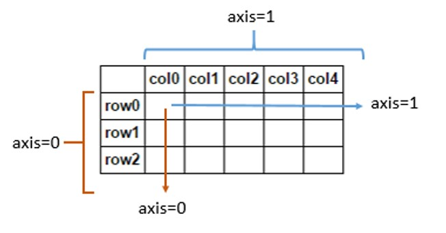

( [출처](https://stackoverflow.com/questions/17079279/how-is-axis-indexed-in-numpys-array) )

```python
mat1 = np.array([[1, 2, 3, 4],
                 [5, 6, 7, 8],
                 [9, 10, 11, 12]], dtype=np.int)
df1 = pd.DataFrame(mat1)
df1
```

|  | 0 | 1 | 2 | 3 |
| --- | --- | --- | --- | --- |
| 0 | 1 | 2 | 3 | 4 |
| 1 | 5 | 6 | 7 | 8 |
| 2 | 9 | 10 | 11 | 12 |

```python
df1.sum(axis = 0) # 반환 값의 타입은 pd.Series이다.
```

```
0    15
1    18
2    21
3    24
dtype: int64
```

```python
df1.sum(axis=1) # 반환 값의 타입은 pd.Series이다.
```

```
0    10
1    26
2    42
dtype: int64
```

## 3.6 operation for 2개의 pd.DataFrame 객체

np.array와 정말 똑같은 pd.Series 객체들간의 연산을 지원한다.

```python
mat1 = np.array([[1, 2, 3, 4],
          [5, 6, 7, 8],
          [9, 10, 11, 12]], dtype = np.int) # 3 X 4

mat2 = np.arange(13, 25, dtype = np.int).reshape(3,4) # 3 X 4

df1 = pd.DataFrame(mat1)
df2 = pd.DataFrame(mat2)
```

```python
df1
```

|  | 0 | 1 | 2 | 3 |
| --- | --- | --- | --- | --- |
| 0 | 1 | 2 | 3 | 4 |
| 1 | 5 | 6 | 7 | 8 |
| 2 | 9 | 10 | 11 | 12 |

```python
df2
```

|  | 0 | 1 | 2 | 3 |
| --- | --- | --- | --- | --- |
| 0 | 13 | 14 | 15 | 16 |
| 1 | 17 | 18 | 19 | 20 |
| 2 | 21 | 22 | 23 | 24 |

```python
df1 + df2
```

|  | 0 | 1 | 2 | 3 |
| --- | --- | --- | --- | --- |
| 0 | 14 | 16 | 18 | 20 |
| 1 | 22 | 24 | 26 | 28 |
| 2 | 30 | 32 | 34 | 36 |

```python
df1 - df2
```

|  | 0 | 1 | 2 | 3 |
| --- | --- | --- | --- | --- |
| 0 | -12 | -12 | -12 | -12 |
| 1 | -12 | -12 | -12 | -12 |
| 2 | -12 | -12 | -12 | -12 |

```python
df1 * df2
```

|  | 0 | 1 | 2 | 3 |
| --- | --- | --- | --- | --- |
| 0 | 13 | 28 | 45 | 64 |
| 1 | 85 | 108 | 133 | 160 |
| 2 | 189 | 220 | 253 | 288 |

```python
df2.T
```

|  | 0 | 1 | 2 |
| --- | --- | --- | --- |
| 0 | 13 | 17 | 21 |
| 1 | 14 | 18 | 22 |
| 2 | 15 | 19 | 23 |
| 3 | 16 | 20 | 24 |

```python
df1.dot(df2.T)
```

|  | 0 | 1 | 2 |
| --- | --- | --- | --- |
| 0 | 150 | 190 | 230 |
| 1 | 382 | 486 | 590 |
| 2 | 614 | 782 | 950 |

```python
pd.concat((df1, df2), axis=0) # index의 중복이 있다
```

|  | 0 | 1 | 2 | 3 |
| --- | --- | --- | --- | --- |
| 0 | 1 | 2 | 3 | 4 |
| 1 | 5 | 6 | 7 | 8 |
| 2 | 9 | 10 | 11 | 12 |
| 0 | 13 | 14 | 15 | 16 |
| 1 | 17 | 18 | 19 | 20 |
| 2 | 21 | 22 | 23 | 24 |

```python
pd.concat((df1, df2), axis=1) # column의 중복이 있다
```

|  | 0 | 1 | 2 | 3 | 0 | 1 | 2 | 3 |
| --- | --- | --- | --- | --- | --- | --- | --- | --- |
| 0 | 1 | 2 | 3 | 4 | 13 | 14 | 15 | 16 |
| 1 | 5 | 6 | 7 | 8 | 17 | 18 | 19 | 20 |
| 2 | 9 | 10 | 11 | 12 | 21 | 22 | 23 | 24 |

```python
pd.concat((df1, df2), axis=1).loc[:,1] # index 중복의 결과로서 2개의 열이 나온다.
```

|  | 1 | 1 |
| --- | --- | --- |
| 0 | 2 | 14 |
| 1 | 6 | 18 |
| 2 | 10 | 22 |

#### 다른 점은 **shape이 다른** 객체들간의 연산도 지원한다는 것이다.

```python
mat1 = np.array([[1, 2, 3, 4, 5],
          [6, 7, 8, 9, 10],
          [11, 12, 13, 14, 15]],dtype=np.int)
df1 = pd.DataFrame(mat1, index=['a', 'b', 'c'],
                   columns=['score1',
                            'score2',
                            'score3',
                            'score4',
                            'score5'])
```

```python
mat2 = np.array([[3, 4, 5, 6],
          [7, 8, 9, 10],
          [11, 12, 13, 14]],dtype=np.int)
df2 = pd.DataFrame(mat2, index=['a', 'b', 'c'],
                   columns=['score3', 'score4', 'score5', 'score6'])
```

```python
df1
```

|  | score1 | score2 | score3 | score4 | score5 |
| --- | --- | --- | --- | --- | --- |
| a | 1 | 2 | 3 | 4 | 5 |
| b | 6 | 7 | 8 | 9 | 10 |
| c | 11 | 12 | 13 | 14 | 15 |

```python
df2
```

|  | score3 | score4 | score5 | score6 |
| --- | --- | --- | --- | --- |
| a | 3 | 4 | 5 | 6 |
| b | 7 | 8 | 9 | 10 |
| c | 11 | 12 | 13 | 14 |

```python
df1 + df2
```

|  | score1 | score2 | score3 | score4 | score5 | score6 |
| --- | --- | --- | --- | --- | --- | --- |
| a | NaN | NaN | 6 | 8 | 10 | NaN |
| b | NaN | NaN | 15 | 17 | 19 | NaN |
| c | NaN | NaN | 24 | 26 | 28 | NaN |

## 3.7 pd.DataFrame with NaN values

```python
df3 = df1 + df2
```

```python
df3
```

|  | score1 | score2 | score3 | score4 | score5 | score6 |
| --- | --- | --- | --- | --- | --- | --- |
| a | NaN | NaN | 6 | 8 | 10 | NaN |
| b | NaN | NaN | 15 | 17 | 19 | NaN |
| c | NaN | NaN | 24 | 26 | 28 | NaN |

```python
df3.isnull()
```

|  | score1 | score2 | score3 | score4 | score5 | score6 |
| --- | --- | --- | --- | --- | --- | --- |
| a | True | True | False | False | False | True |
| b | True | True | False | False | False | True |
| c | True | True | False | False | False | True |

```python
df3.where(df3.notnull())
```

|  | score1 | score2 | score3 | score4 | score5 | score6 |
| --- | --- | --- | --- | --- | --- | --- |
| a | NaN | NaN | 6 | 8 | 10 | NaN |
| b | NaN | NaN | 15 | 17 | 19 | NaN |
| c | NaN | NaN | 24 | 26 | 28 | NaN |

```python
df3_1 = pd.DataFrame(np.array([np.nan, np.nan, np.nan,
                               np.nan, np.nan, np.nan]).reshape(1,-1),
                     index = ['d'],
                     columns = ['score1', 'score2',
                                'score3', 'score4', 'score5', 'score6'])
df3_1
```

|  | score1 | score2 | score3 | score4 | score5 | score6 |
| --- | --- | --- | --- | --- | --- | --- |
| d | NaN | NaN | NaN | NaN | NaN | NaN |

```python
pd.concat((df3, df3_1), axis = 0)
```

|  | score1 | score2 | score3 | score4 | score5 | score6 |
| --- | --- | --- | --- | --- | --- | --- |
| a | NaN | NaN | 6.0 | 8.0 | 10.0 | NaN |
| b | NaN | NaN | 15.0 | 17.0 | 19.0 | NaN |
| c | NaN | NaN | 24.0 | 26.0 | 28.0 | NaN |
| d | NaN | NaN | NaN | NaN | NaN | NaN |

```python
df3.where(df3.notnull())
```

|  | score1 | score2 | score3 | score4 | score5 | score6 |
| --- | --- | --- | --- | --- | --- | --- |
| a | NaN | NaN | 6 | 8 | 10 | NaN |
| b | NaN | NaN | 15 | 17 | 19 | NaN |
| c | NaN | NaN | 24 | 26 | 28 | NaN |

```python
df3.where(df3.notnull()).dropna(axis = 0)
```

|  | score1 | score2 | score3 | score4 | score5 | score6 |
| --- | --- | --- | --- | --- | --- | --- |

```python
df3.where(df3.notnull()).dropna(axis = 1)
```

|  | score3 | score4 | score5 |
| --- | --- | --- | --- |
| a | 6 | 8 | 10 |
| b | 15 | 17 | 19 |
| c | 24 | 26 | 28 |

## 3.8 pd.DataFrame.index(or columms).name

생각보다 자주 쓴다.

```python
df3
```

|  | score1 | score2 | score3 | score4 | score5 | score6 |
| --- | --- | --- | --- | --- | --- | --- |
| a | NaN | NaN | 6 | 8 | 10 | NaN |
| b | NaN | NaN | 15 | 17 | 19 | NaN |
| c | NaN | NaN | 24 | 26 | 28 | NaN |

```python
df3.index.name = 'idx_name'
```

```python
df3.columns.name = 'exam'
```

```python
df3
```

| exam idx_name | score1 | score2 | score3 | score4 | score5 | score6 |
| --- | --- | --- | --- | --- | --- | --- |
| a | NaN | NaN | 6 | 8 | 10 | NaN |
| b | NaN | NaN | 15 | 17 | 19 | NaN |
| c | NaN | NaN | 24 | 26 | 28 | NaN |

# 4. Series와 DF객체를 가지고 자주 만나게 될 기본 task들

> 1. Reindex
> 2. Dropping 관측치 or 변수
> 3. 함수 적용
> 4. 정렬
> 5. Summary statistics
> 6. filter/fill NA

## 4.1 Reindex

아까 pd.Index는 immutable하여서 안정적이고 쉽게 변경하지 못하게 만들어놨는데

순서정도를 바꿀 일은 흔하다.

```python
sr1 = pd.Series([91, 100, 93, 94], index = list('abcd'))
```

```python
sr1
```

```
a     91
b    100
c     93
d     94
dtype: int64
```

```python
sr1.reindex(['kim','a', 'b', 'c', 'd'])
```

```
kim      NaN
a       91.0
b      100.0
c       93.0
d       94.0
dtype: float64
```

```python
sr1.reindex(['kim','a', 'b', 'c', 'd'], fill_value = 0)
```

```
kim      0
a       91
b      100
c       93
d       94
dtype: int64
```

```python
sr1.reindex(['kim','d', 'c', 'b', 'a'], fill_value = 0)
```

```
kim      0
d       94
c       93
b      100
a       91
dtype: int64
```

```python
mat1 = np.array([[1, 2, 3, 4],
          [5, 6, 7, 8],
          [9, 10, 11, 12]],dtype = np.int)
df1 = pd.DataFrame(mat1, index = ['a', 'b', 'c'],
                   columns = ['score1', 'score2', 'score3', 'score4'])
```

```python
df1
```

|  | score1 | score2 | score3 | score4 |
| --- | --- | --- | --- | --- |
| a | 1 | 2 | 3 | 4 |
| b | 5 | 6 | 7 | 8 |
| c | 9 | 10 | 11 | 12 |

```python
df1.reindex(index = ['c', 'a'], columns = ['score1', 'score5', 'score4'])
```

|  | score1 | score5 | score4 |
| --- | --- | --- | --- |
| c | 9.0 | NaN | 12.0 |
| a | 1.0 | NaN | 4.0 |

```python
import this
```

[output not shown]

## 4.2 Dropping 관측치 or 변수

```python
sr1 = pd.Series([91, 100, 93, 94], index = ['a', 'd', 'c', 'b'])

mat1 = np.array([[1, 2, 3, 4],
          [5, 6, 7, 8],
          [9, 10, 11, 12]],dtype = np.int)
df1 = pd.DataFrame(mat1, index = ['a', 'b', 'c'],
                   columns = ['score1', 'score2', 'score3', 'score4'])
```

```python
sr1
```

```
a     91
d    100
c     93
b     94
dtype: int64
```

```python
sr1.drop('c')
```

```
a     91
d    100
b     94
dtype: int64
```

```python
sr1
```

```
a     91
d    100
c     93
b     94
dtype: int64
```

```python
df1
```

|  | score1 | score2 | score3 | score4 |
| --- | --- | --- | --- | --- |
| a | 1 | 2 | 3 | 4 |
| b | 5 | 6 | 7 | 8 |
| c | 9 | 10 | 11 | 12 |

```python
df1.drop('b')
```

|  | score1 | score2 | score3 | score4 |
| --- | --- | --- | --- | --- |
| a | 1 | 2 | 3 | 4 |
| c | 9 | 10 | 11 | 12 |

```python
df1
```

|  | score1 | score2 | score3 | score4 |
| --- | --- | --- | --- | --- |
| a | 1 | 2 | 3 | 4 |
| b | 5 | 6 | 7 | 8 |
| c | 9 | 10 | 11 | 12 |

```python
df1.drop(['score1', 'score3'], axis = 1)
```

|  | score2 | score4 |
| --- | --- | --- |
| a | 2 | 4 |
| b | 6 | 8 |
| c | 10 | 12 |

## 4.3 함수 적용

```python
df1 = pd.DataFrame(np.random.randn(9).reshape(3,3),
                   index=['stu1', 'stu2', 'stu3'],
                   columns=['exam1', 'exam2', 'exam3'])
```

```python
df1
```

|  | exam1 | exam2 | exam3 |
| --- | --- | --- | --- |
| stu1 | 0.572067 | 0.220479 | -0.095354 |
| stu2 | -0.176753 | 0.010580 | -0.843975 |
| stu3 | 0.597334 | -0.656116 | -0.397884 |

#### DataFrame에서 한 observation에 대한 함수 적용도 흔하고 한 variable에 대한 함수 적용도 흔하다.

```python
f_length = lambda x: x.max() - x.min()
f_length
```

```
<function __main__.<lambda>(x)>
```

**lambda**는 functional programming 문법이다. 개념 자체가 정말 어려우니 느낌만 받고 써도 무방하다.

functional : 인수에 함수를 적용하여 값을 반환하는 함수

```python
# exam별 최고점자와 최저점자의 점수 차이
df1.apply(f_length)
```

```
exam1    0.774087
exam2    0.876595
exam3    0.748621
dtype: float64
```

```python
# 학생별 최고점과 최저점의 점수 차이
df1.apply(f_length, axis=1)
```

```
stu1    0.667421
stu2    0.854555
stu3    1.253450
dtype: float64
```

```python
df1.apply(np.mean)
```

```
exam1    0.330883
exam2   -0.141686
exam3   -0.445738
dtype: float64
```

```python
df1.apply(max)
```

```
exam1    0.597334
exam2    0.220479
exam3   -0.095354
dtype: float64
```

#### DataFrame에서 각 element에 대한 함수 적용도 한다.

```python
f_double = lambda x: 2 * x
```

```python
df1.applymap(f_double)
```

|  | exam1 | exam2 | exam3 |
| --- | --- | --- | --- |
| stu1 | 1.144134 | 0.440958 | -0.190709 |
| stu2 | -0.353506 | 0.021160 | -1.687951 |
| stu3 | 1.194669 | -1.312232 | -0.795768 |

```python
f_format = lambda x: '{0:.2f}'.format(x) #정규식(RegEx: Regular Expression)
```

```python
df1.applymap(f_format)
```

|  | exam1 | exam2 | exam3 |
| --- | --- | --- | --- |
| stu1 | 0.57 | 0.22 | -0.10 |
| stu2 | -0.18 | 0.01 | -0.84 |
| stu3 | 0.60 | -0.66 | -0.40 |

## 4.4 Sorting and ranking

```python
sr1 = pd.Series([91, 100, 93, 94], index=['b', 'd', 'c', 'a'])
```

```python
sr1
```

```
b     91
d    100
c     93
a     94
dtype: int64
```

```python
sr1.sort_index()
```

```
a     94
b     91
c     93
d    100
dtype: int64
```

```python
sr1.sort_values()
```

```
b     91
c     93
a     94
d    100
dtype: int64
```

```python
sr1.rank()
```

```
b    1.0
d    4.0
c    2.0
a    3.0
dtype: float64
```

```python
sr1.rank(ascending = False)
```

```
b    4.0
d    1.0
c    3.0
a    2.0
dtype: float64
```

```python
df1 = pd.DataFrame(np.random.randn(9).reshape(3,3),
                   index=['stu1', 'stu2', 'stu3'],
                   columns=['exam3', 'exam2', 'exam1'])
```

```python
df1
```

|  | exam3 | exam2 | exam1 |
| --- | --- | --- | --- |
| stu1 | -0.123917 | 1.158776 | 0.288028 |
| stu2 | -0.493977 | -0.435837 | 0.186696 |
| stu3 | 0.058786 | 0.584903 | 0.242051 |

```python
df1.sort_index(axis = 1)
```

|  | exam1 | exam2 | exam3 |
| --- | --- | --- | --- |
| stu1 | 0.288028 | 1.158776 | -0.123917 |
| stu2 | 0.186696 | -0.435837 | -0.493977 |
| stu3 | 0.242051 | 0.584903 | 0.058786 |

```python
df1.sort_index(axis=1, ascending=False)
```

|  | exam3 | exam2 | exam1 |
| --- | --- | --- | --- |
| stu1 | -0.123917 | 1.158776 | 0.288028 |
| stu2 | -0.493977 | -0.435837 | 0.186696 |
| stu3 | 0.058786 | 0.584903 | 0.242051 |

```python
df1.sort_values(by = 'exam3')
```

|  | exam3 | exam2 | exam1 |
| --- | --- | --- | --- |
| stu2 | -0.493977 | -0.435837 | 0.186696 |
| stu1 | -0.123917 | 1.158776 | 0.288028 |
| stu3 | 0.058786 | 0.584903 | 0.242051 |

```python
df1.sort_values(by = ['exam3', 'exam1']) # exam3 순으로 먼저 sort하고 그 다음 exam1 순으로 sort
```

|  | exam3 | exam2 | exam1 |
| --- | --- | --- | --- |
| stu2 | -0.493977 | -0.435837 | 0.186696 |
| stu1 | -0.123917 | 1.158776 | 0.288028 |
| stu3 | 0.058786 | 0.584903 | 0.242051 |

```python
df1.rank()
```

|  | exam3 | exam2 | exam1 |
| --- | --- | --- | --- |
| stu1 | 2.0 | 3.0 | 3.0 |
| stu2 | 1.0 | 1.0 | 1.0 |
| stu3 | 3.0 | 2.0 | 2.0 |

```python
df1.rank(axis=1)
```

|  | exam3 | exam2 | exam1 |
| --- | --- | --- | --- |
| stu1 | 1.0 | 3.0 | 2.0 |
| stu2 | 1.0 | 2.0 | 3.0 |
| stu3 | 1.0 | 3.0 | 2.0 |

## 4.5 Summary statistics

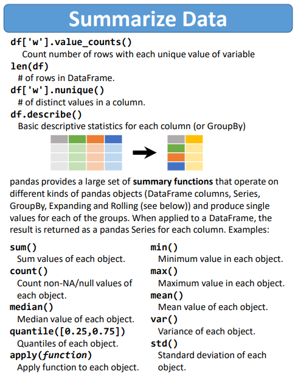

( [출처](https://pandas.pydata.org/Pandas_Cheat_Sheet.pdf) )

```python
df1 = pd.DataFrame({'major' : ['stat', 'stat', 'CS', 'CS', 'math'],
                    'score1': np.arange(100,90,-2),
                    'score2': np.arange(90,100,2)},
                   index=['lee', 'kim', 'park', 'cho', 'song'])
```

```python
df1
```

|  | major | score1 | score2 |
| --- | --- | --- | --- |
| lee | stat | 100 | 90 |
| kim | stat | 98 | 92 |
| park | CS | 96 | 94 |
| cho | CS | 94 | 96 |
| song | math | 92 | 98 |

```python
# score만 뽑아보자.
df1.iloc[:, 1:3]
```

|  | score1 | score2 |
| --- | --- | --- |
| lee | 100 | 90 |
| kim | 98 | 92 |
| park | 96 | 94 |
| cho | 94 | 96 |
| song | 92 | 98 |

```python
# 과목별 평균만 뽑아보자.
df1.iloc[:, 1:3].mean(axis = 0)
```

```
score1    96.0
score2    94.0
dtype: float64
```

```python
# 과목별 최우수자만 뽑아보자.
df1.iloc[:, 1:3].idxmax()
```

```
score1     lee
score2    song
dtype: object
```

```python
df1.describe()
```

|  | score1 | score2 |
| --- | --- | --- |
| count | 5.000000 | 5.000000 |
| mean | 96.000000 | 94.000000 |
| std | 3.162278 | 3.162278 |
| min | 92.000000 | 90.000000 |
| 25% | 94.000000 | 92.000000 |
| 50% | 96.000000 | 94.000000 |
| 75% | 98.000000 | 96.000000 |
| max | 100.000000 | 98.000000 |

```python
df1.major.value_counts()
```

```
stat    2
CS      2
math    1
Name: major, dtype: int64
```

```python
df1.corr()
```

|  | score1 | score2 |
| --- | --- | --- |
| score1 | 1.0 | -1.0 |
| score2 | -1.0 | 1.0 |

## 4.6 filter/fill NA

### 4.6.1 filter NA

```python
sr1 = pd.Series([np.nan, 2., np.nan, 4.])
```

```python
sr1
```

```
0    NaN
1    2.0
2    NaN
3    4.0
dtype: float64
```

```python
sr1.dropna()
```

```
1    2.0
3    4.0
dtype: float64
```

```python
sr1[sr1.notnull()]
```

```
1    2.0
3    4.0
dtype: float64
```

```python
df1 = pd.DataFrame([[1, 2, 3, 4],
                    [np.nan, 2., np.nan, 4.],
                    [np.nan, 3, 4, 5]])
```

```python
df1
```

|  | 0 | 1 | 2 | 3 |
| --- | --- | --- | --- | --- |
| 0 | 1.0 | 2.0 | 3.0 | 4.0 |
| 1 | NaN | 2.0 | NaN | 4.0 |
| 2 | NaN | 3.0 | 4.0 | 5.0 |

```python
df1.columns = ['exam1', 'exam2', 'exam3', 'exam4']
```

```python
df1.index = ['stu1', 'stu2', 'stu3']
```

```python
df1
```

|  | exam1 | exam2 | exam3 | exam4 |
| --- | --- | --- | --- | --- |
| stu1 | 1.0 | 2.0 | 3.0 | 4.0 |
| stu2 | NaN | 2.0 | NaN | 4.0 |
| stu3 | NaN | 3.0 | 4.0 | 5.0 |

```python
df1.dropna()
```

|  | exam1 | exam2 | exam3 | exam4 |
| --- | --- | --- | --- | --- |
| stu1 | 1.0 | 2.0 | 3.0 | 4.0 |

```python
df1.dropna(axis = 1)
```

|  | exam2 | exam4 |
| --- | --- | --- |
| stu1 | 2.0 | 4.0 |
| stu2 | 2.0 | 4.0 |
| stu3 | 3.0 | 5.0 |

```python
df2 = pd.DataFrame([np.nan, np.nan, np.nan, np.nan]).T
df2.columns = ['exam1', 'exam2', 'exam3', 'exam4']
df2.index =  ['stu4']
```

```python
df3 = pd.concat((df1, df2), axis=0)
df3
```

|  | exam1 | exam2 | exam3 | exam4 |
| --- | --- | --- | --- | --- |
| stu1 | 1.0 | 2.0 | 3.0 | 4.0 |
| stu2 | NaN | 2.0 | NaN | 4.0 |
| stu3 | NaN | 3.0 | 4.0 | 5.0 |
| stu4 | NaN | NaN | NaN | NaN |

```python
df3.dropna(how = 'all')
```

|  | exam1 | exam2 | exam3 | exam4 |
| --- | --- | --- | --- | --- |
| stu1 | 1.0 | 2.0 | 3.0 | 4.0 |
| stu2 | NaN | 2.0 | NaN | 4.0 |
| stu3 | NaN | 3.0 | 4.0 | 5.0 |

```python
df3.dropna(how = 'any')
```

|  | exam1 | exam2 | exam3 | exam4 |
| --- | --- | --- | --- | --- |
| stu1 | 1.0 | 2.0 | 3.0 | 4.0 |

### 4.6.2 fill NA

```python
df3
```

|  | exam1 | exam2 | exam3 | exam4 |
| --- | --- | --- | --- | --- |
| stu1 | 1.0 | 2.0 | 3.0 | 4.0 |
| stu2 | NaN | 2.0 | NaN | 4.0 |
| stu3 | NaN | 3.0 | 4.0 | 5.0 |
| stu4 | NaN | NaN | NaN | NaN |

```python
df3.fillna(0) # 0점으로 결측치를 채우자!
```

|  | exam1 | exam2 | exam3 | exam4 |
| --- | --- | --- | --- | --- |
| stu1 | 1.0 | 2.0 | 3.0 | 4.0 |
| stu2 | 0.0 | 2.0 | 0.0 | 4.0 |
| stu3 | 0.0 | 3.0 | 4.0 | 5.0 |
| stu4 | 0.0 | 0.0 | 0.0 | 0.0 |

```python
{'exam1': df3.exam1.mean(), 'exam2': df3.exam2.mean(),
            'exam3': df3.exam3.mean(), 'exam4': df3.exam4.mean()}
```

```
{'exam1': 1.0,
 'exam2': 2.3333333333333335,
 'exam3': 3.5,
 'exam4': 4.333333333333333}
```

```python
df3.fillna(
    {'exam1': df3.exam1.mean(), 'exam2': df3.exam2.mean(),
            'exam3': df3.exam3.mean(), 'exam4': df3.exam4.mean()}
) # 평균으로 결측치를 채우자!
```

|  | exam1 | exam2 | exam3 | exam4 |
| --- | --- | --- | --- | --- |
| stu1 | 1.0 | 2.000000 | 3.0 | 4.000000 |
| stu2 | 1.0 | 2.000000 | 3.5 | 4.000000 |
| stu3 | 1.0 | 3.000000 | 4.0 | 5.000000 |
| stu4 | 1.0 | 2.333333 | 3.5 | 4.333333 |

```python
df1 = pd.DataFrame({'CustomerId' : range(1, 11), 'Menu' : ("Kimbab " * 3 + "Bibimbab " * 3 + "Odeng " * 4).split()})
```

```python
df1
```

|  | CustomerId | Menu |
| --- | --- | --- |
| 0 | 1 | Kimbab |
| 1 | 2 | Kimbab |
| 2 | 3 | Kimbab |
| 3 | 4 | Bibimbab |
| 4 | 5 | Bibimbab |
| 5 | 6 | Bibimbab |
| 6 | 7 | Odeng |
| 7 | 8 | Odeng |
| 8 | 9 | Odeng |
| 9 | 10 | Odeng |

```python
df1 = pd.DataFrame({'CustomerId' : range(1, 11),
                    'Menu' : ("Kimbab " * 3 + "Bibimbab " * 3 + "Odeng " * 4).split()})
df2 = pd.DataFrame({'CustomerId' : [2, 4, 6], 'Table' : ("SectorA " * 2 + "SectorB").split()})
df3 = pd.DataFrame({'CustomerId' : [2, 5], 'Gender' : ["Male", "Female"]})
```

```python
df1
```

|  | CustomerId | Menu |
| --- | --- | --- |
| 0 | 1 | Kimbab |
| 1 | 2 | Kimbab |
| 2 | 3 | Kimbab |
| 3 | 4 | Bibimbab |
| 4 | 5 | Bibimbab |
| 5 | 6 | Bibimbab |
| 6 | 7 | Odeng |
| 7 | 8 | Odeng |
| 8 | 9 | Odeng |
| 9 | 10 | Odeng |

```python
df2
```

|  | CustomerId | Table |
| --- | --- | --- |
| 0 | 2 | SectorA |
| 1 | 4 | SectorA |
| 2 | 6 | SectorB |

```python
df3
```

|  | CustomerId | Gender |
| --- | --- | --- |
| 0 | 2 | Male |
| 1 | 5 | Female |

```python
df4 = pd.merge(df1, df2, on="CustomerId", how='outer')
df4
df5 = pd.merge(df4, df3, on="CustomerId", how='left')
df5
```

|  | CustomerId | Menu | Table | Gender |
| --- | --- | --- | --- | --- |
| 0 | 1 | Kimbab | NaN | NaN |
| 1 | 2 | Kimbab | SectorA | Male |
| 2 | 3 | Kimbab | NaN | NaN |
| 3 | 4 | Bibimbab | SectorA | NaN |
| 4 | 5 | Bibimbab | NaN | Female |
| 5 | 6 | Bibimbab | SectorB | NaN |
| 6 | 7 | Odeng | NaN | NaN |
| 7 | 8 | Odeng | NaN | NaN |
| 8 | 9 | Odeng | NaN | NaN |
| 9 | 10 | Odeng | NaN | NaN |